# Prevalence of Central Obesity in Nigeria; A Systematic Review and Meta-Analysis

M. A. Bashir<sup>1,*</sup> , A. I. Yahaya<sup>1</sup>, Mukhtar Muhammad<sup>1</sup>, A.H. Yusuf<sup>1</sup>, I.G. Mukhtar<sup>2</sup>

2021-09-11

**Keywords**: Obesity, Nigeria, Waist Circumference, Systematic Review, Meta-analysis

# 1 INTRODUCTION

Obesity is an excessive accumulation of fat in adipose tissue causing an impairment of health[1]. For any given amount of total body fat, there is great variation in the pattern of regional fat distribution with men having about twice the amount of abdominal fat found in pre-menopausal women[2]. Waist Circumference is a good correlate of abdominal fat and thus used to measure central or abdominal obesity i.e. an excessive accumulation of abdominal fat[3]. The Third Report of the National Cholesterol Education Program (NCEP) Expert Panel on Detection, Evaluation, and Treatment of High Blood Cholesterol in Adults (ATP III) defines central obesity as waist circumference of above 102 cm for males and above 88 cm for females[4]. Definitions of central obesity by the The International Diabetes Federation (IDF) are not only gender-specific but ethnicity-specific as well with Europoids cut off values of above 94 cm for males and above 80 cm for females; these values are recommended for African populations until more data are available[5].

A recent meta-analysis of 288 studies conducted worldwide and involving 13,233,675 individuals showed that the prevalence of central obesity is rising from 31.3% in the years 1985–1999 to 48.3% in the years 2010–2014. This increase was found to be higher in males s (from 25.3 to 41.6%) compared with females (from 38.6 to 49.7%). Prevalence of central obesity in Africa was found to be high at 49.7% even though the region is dominated by low and middle income countries[6].

Waist circumference is not only correlated to abdominal fat but also to diabetes, cardiovascular disease and all cause mortality. In a meta-analysis of 50 studies conducted worldwide and involving 2056428 individuals, it was found that a 10 cm increase in waist circumference was associated with 11% higher risk of all cause mortality and this association remained significant and even strengthened after controlling for body mass index[7]. In another meta-analysis of 23 longitudinal observation studies involving 62 study arms with 259,200 individuals, WC above 102 cm in males and above 88 cm in females was a better predictor than BMI above 30kg/m<sup>2</sup> for development of diabetes; this finding was especially strong for women and those above age of 60 years[8].

Despite the importance of central obesity in relation to diabetes, cardiovascular disease and all cause mortality, there are no systematic reviews and meta-analyses of the prevalence of abdominal obesity in Nigeria. This study aims to estimate the overall, sex-specific and region-specific prevalence rates of central obesity in the country.

# 2 METHODOLOGY

The systematic review and meta-analysis was conducted according to the Meta-analysis of Observational Studies in Epidemiology (MOOSE) guidelines[9].

## 2.1 Study Area

Nigeria is a western African nation with an area of 923,769 sq km, home to more than 250 ethnic groups [10]. It has 36 states and a capital divided into 6 geo-political zones or regions; 3 regions each in the northern and southern parts of the country. The estimated population in 2021 is 211.4 million. 43.4% of the population are under the age of 14 years. 53.9% of the population are between the ages of 15 and 64 years. Only 2.8% of the population are above the age of 65 years.[11]. Supplementary material S1 shows the map of the geopolitical zones of the country.

## 2.2 Inclusion and Exclusion Criteria

Included in this systematic review are population-based studies in Nigeria conducted in individuals aged 15-65 years. Included studies must use either the IDF or NCEP ATP III criteria for diagnosing central obesity. Excluded from this review are studies conducted in pregnant women, studies failing to report prevalence of or the criteria used in defining central obesity and all hospital-based studies.

## 2.3 Studies Search Strategies

Online databases used were Google Scholar, PubMed and Scopus. Search words and phrases used were: ‘waist circumference,’ ‘central obesity,’ ‘central adiposity’ and ‘abdominal obesity.’Search was repeated for each word or phrase with the name ‘Nigeria.’ Search was conducted between May 2021 to August 2021. Screening of the abstracts and titles of the articles was done independently by two reviewers (AHY and IGM) and studies selection and exclusion done based on the predefined criteria. Thereafter, screening of the full-text articles was done independently by the same researchers to select the studies to be included in qualitative and quantitative analyses.

The methodological quality of the included studies was assessed using a modification of the Joanna Briggs Institute (JBI) Critical Appraisal Checklist for Studies Reporting Prevalence Data[12]. The item’s original 9 questions were reduced to six (6) with questions one (1) and two (2) were given a score of two (2) and the remaining four (4) question each given a score of one (1) for a ‘yes’ and zero (0) for a ‘no.’ The total maximum score is eight(8). A study was judged as good quality if it scored minimum of six (6) and of poor quality if it scores less than six (6). Assessment was done independently by two reviewers (AHY and MM) with disagreements sorted by AIH. Supplemental Material S2 shows the modified tool used in critical appraisal of the included studies. The minimum sample size for scoring a study as a ‘yes’ was one hundred and ninety (190) calculated using Epitools[13] online calculator assuming an estimated prevalence of 14.3%, which is the prevalence of generalized obesity in Nigeria based on a recent meta-analysis. Validity of methods was assessed based on whether trained anthropometrists took the waist circumference measurements whereas reliability was assessed based on whether measurements were taken using a consistent landmark (e.g at iliac crest or midpoint between rib cage and iliac crest) . Only studies judged as having good methodological quality were included in the quantitative analysis.

## 2.7 Publication Bias Assessment

# 3 RESULTS

## 3.1 Search Results

Figure 3.1 shows the results of the search strategy.

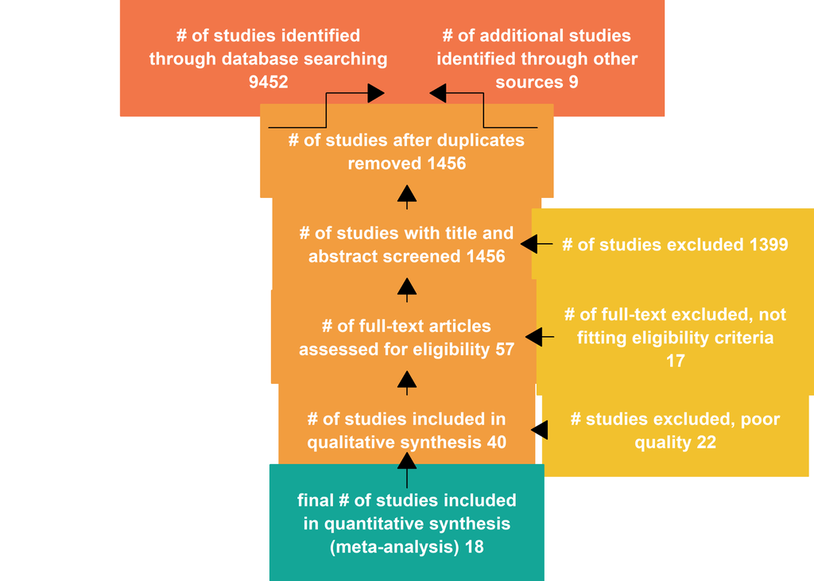

Figure 3.1: Results of the Search

[output not shown]

## 3.2 Methodological features and the Critical Appraisal of the Included Studies

40 studies were selected and included in the qualitative analysis of methodological features. The quality appraisal of the included studies is shown in the supplemental material S3.

## 3.3 Characteristics of the Studies Included in the Quantitative Analysis

18 studies consisting of 21859 individuals met the inclusion criteria and are of good or moderate quality and thus included in the meta-analysis. The studies were conducted between 1996 and 2021. There were 2 studies from the north-west region; 1(one) conducted in an urban settlement and the other conducted in both rural and urban settlements. Similarly, there were 2 studies from the north_central 1(one) conducted in an urban settlement and the other conducted in both rural and urban settlements. There were 6 studies from the south-east with 1 study conducted in an urban, 2 studies in a rural and 3 studies in both rural and urban settlements. There is only 1 study conducted in the south-south region.Similarly, there is only 1 study conducted in the north-east region . 6 studies were conducted in the south-west region including 4 studies in urban areas, 1 study in a rural area and 1 study conducted in both urban and rural areas. Overall, eight(8) studies were conducted in the urban settlements only, three(3) studies were conducted in rural settlements only and 7 studies were conducted in both rural and urban settlements (Figure 3.2).

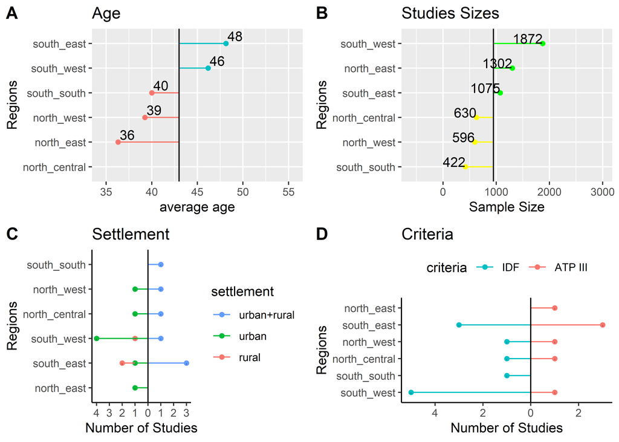

Figure 3.2: Characteristics of the Included Studies

## 3.4 Fitting the Meta Analytic Models

Random Effects Model was fitted using inverse variance method with correction of pooled estimate and its variance using Sidik-Jonkman’s estimator for between study heterogeneity. Prevalence rates were tranformed using arcsine transformation and means were log transformed. Figure 3.3 shows the forest plot of the models. The pooled prevalence of central obesity under the IDF criteria,39% (95% CI: 25%-54%), is higher than the value of 24% (95% CI: 12%-38%) under the ATP III criteria. The *P* values for the random meta analytic model is 0.141, the estimated total between studies heterogeneity not explained by sampling error (I<sup>2</sup>) is 99%. Test for Heterogeneity is significant with p-value<0.001 indicating substantial heterogeneity between the included studies. The prediction interval of the pooled prevalence is 2.2%-73.9%.

The overall mean waist circumference in Nigeria is 83.8cm (95% CI: 80.8cm-86.8cm). The *P* values for the pooled mean model is <0.001, the estimated total between studies heterogeneity not explained by sampling error (I<sup>2</sup>) is 99.8%. Test for Heterogeneity is significant with p-value<0.001 indicating substantial heterogeneity between the included studies. The prediction interval of the pooled mean waist circumference is 72.9cm-96.2cm.

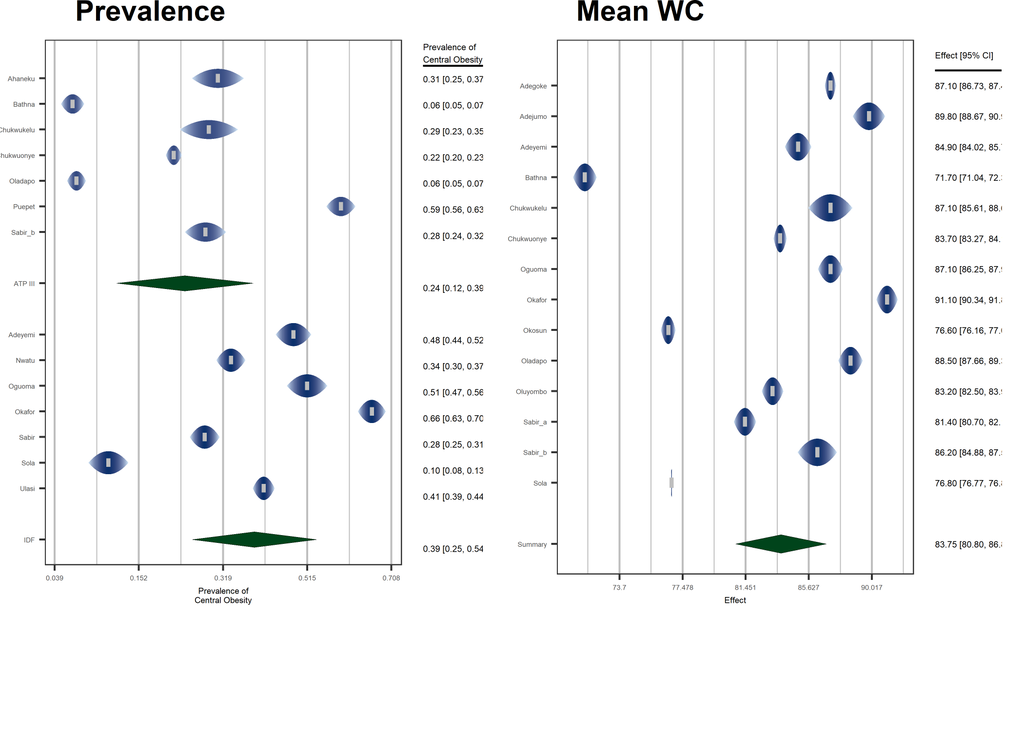

Figure 3.3: forest plots of Pooled Central Obesity and Mean Waist Circumference

## 3.5 Models’ Diagnostics

Supplemental Materials S4 and S5 showed the graphical output of the influence analysis of the pooled central obesity prevalence and mean waist circumference models respectively. No study was tagged influential in both models.

## 3.6 Analysis of Between-Study Heterogeneity; Meta-regression using Studies Characteristics as Predictors

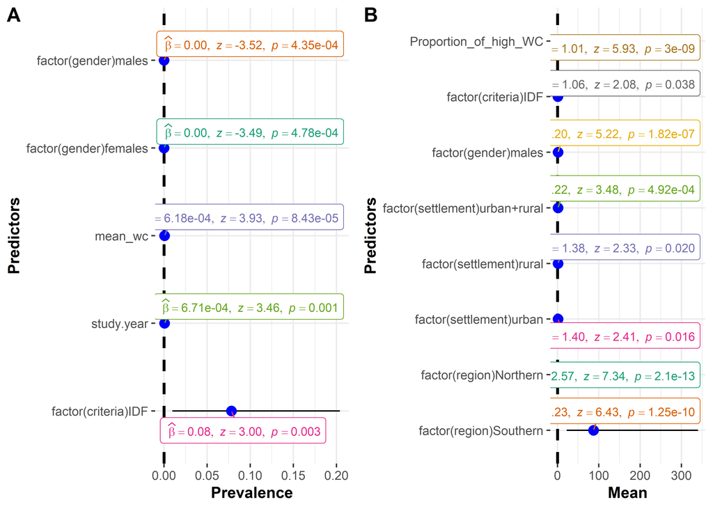

## 3.7 Analysis of Publication Bias

The funnel plots of the pooled prevalence and mean waist circumfernce models are shown is Supplemental Material S8. There was no obvious asymmetry in the plots. Formal test for plot asymmetery (regression test) was conducted and it was not statistically significant (*P* value is 0.597 and 0.114 for the pooled prevalence rate and mean waist circumference respectively), confirming the visual assessment of the funnel plot.

## 3.8 Sub-group Analyses of Mean Waist Circumference

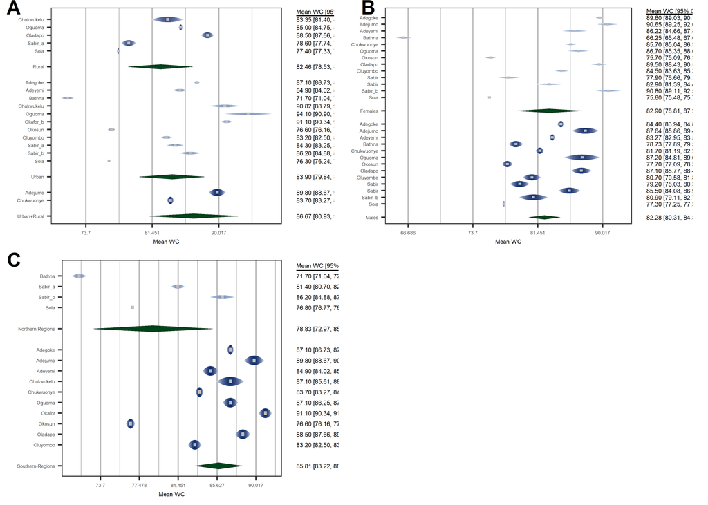

Figure 3.4: Mean Waist Circumference by Settlement (A), Gender (B) and Region(C)

## 3.9 Sub-group Analyses of Central Obesity Prevalence

As shown in Table 3.1, Estimates of prevalence under the IDF criteria are consistently higher than estimates under the ATP III criteria. Additionally, females, Urban residents and individuals from the southern regions have consistently higher prevalence rates of central obesity under both ATP III and IDF criteria than their Males, Rural and Northern region residents counterparts. The exception is the prevalence of central obesity in the Northern regions under the ATP III which was found to be higher than the corresponding estimate in the southern regions.

Table 3.1: Prevalence Rates by Gender, Area of Residence and Region

[output not shown]

# 4 DISCUSSION

Analysis of heterogeneity in this analysis reveals different behaviours for the two measures of heterogeneity; I<sup>2</sup> and tau<sup>2</sup>. The former is known to be sensitive to the size of studies i.e. if the included studies are fairly large then the sampling error will be close to zero and I<sup>2</sup> as a ratio will approach 100%[18]. To measure, with a precision of 0.05 and 95% confidence interval, a central obesity prevalence of 39% found in this study(under IDF criteria), the minimum sample size required is Three Hundred and Sixty Six [13]. The studies included in this meta-analysis are, by the selection criteria, relatively large with sample sizes having an interquartile range of 959. Consequently, I<sup>2</sup> might be closer to 100% even if the between study heterogeneity is not substantial. This is likely the case as a metaregression reduced the tau<sup>2</sup> by almost 87%. However, I<sup>2</sup> barely changed (Supplementary Material S6). The prediction intervals for the pooled prevalence of central obesity (2%-74%) means the possible values members of a population of highly heterogeneous studies conducted or to be conducted in Nigeria could find.

The higher prevalence of central obesity among females compared to males reflects the fact that females and males have similar mean waist circumference. Considering the fact that, central obesity in females is defined at a lower waist circumference value under both ATP III and IDF criteria, similar mean waist circumference in the two sexes will mean higher prevalence rates of obesity among females. Similar higher prevalence in females was found in measure of generalized obesity (BMI) in Nigeria[17]. This is also a trend observed globally [6]. In Nigeria, this may be due to the fact that women are less active than men as found in a recent meta-analysis [19]. This sexual dimorphism in central obesity was also known to be underlined by biological factors with the male hormone,testosterone, known to favoring greater central fat deposition[20].

1.

WHO Consultation on Obesity (1999: Geneva S, Organization WH. Obesity : preventing and managing the global epidemic : report of a WHO consultation [Internet]. World Health Organization; 2000 [cited 2021 Sep 3]. Available from: https://apps.who.int/iris/handle/10665/42330

2.

Lemieux S, Prud’homme D, Bouchard C, Tremblay A, Després JP. Sex differences in the relation of visceral adipose tissue accumulation to total body fatness. The American Journal of Clinical Nutrition. 1993 Oct;58(4):463–7.

3.

Pouliot MC, Després JP, Lemieux S, Moorjani S, Bouchard C, Tremblay A, et al. Waist circumference and abdominal sagittal diameter: Best simple anthropometric indexes of abdominal visceral adipose tissue accumulation and related cardiovascular risk in men and women. The American Journal of Cardiology. 1994 Mar;73(7):460–8.

4.

Expert Panel on Detection, Evaluation, and Treatment of High Blood Cholesterol in Adults. Executive Summary of the Third Report of the National Cholesterol Education Program (NCEP) Expert Panel on Detection, Evaluation, and Treatment of High Blood Cholesterol in Adults (Adult Treatment Panel III). JAMA: The Journal of the American Medical Association. 2001 May;285(19):2486–97.

5.

Alberti KGMM, Zimmet P, Shaw J. Metabolic syndromea new world-wide definition. A Consensus Statement from the International Diabetes Federation. Diabetic Medicine. 2006;23(5):469–80.

6.

Wong MCS, Huang J, Wang J, Chan PSF, Lok V, Chen X, et al. Global, regional and time-trend prevalence of central obesity: A systematic review and meta-analysis of 13.2 million subjects. European Journal of Epidemiology. 2020;35(7):673–83.

7.

Jayedi A, Soltani S, Zargar MS, Khan TA, Shab-Bidar S. Central fatness and risk of all cause mortality: Systematic review and dose-response meta-analysis of 72 prospective cohort studies. BMJ (Clinical research ed). 2020 Sep;370:m3324.

8.

Seo D-C, Choe S, Torabi MR. Is waist circumference $\geq$102/88cm better than body mass index $\geq$30 to predict hypertension and diabetes development regardless of gender, age group, and race/ethnicity? Meta-analysis. Preventive Medicine. 2017 Apr;97:100–8.

9.

Stroup DF, Berlin JA, Morton SC, Olkin I, Williamson GD, Rennie D, et al. Meta-analysis of observational studies in epidemiology: A proposal for reporting. Meta-analysis Of Observational Studies in Epidemiology (MOOSE) group. JAMA. 2000 Apr;283(15):2008–12.

10.

Udo KR, Ajayi JFA, Kirk-Greene AHM, Falola TO. Nigeria. Encyclopedia Britannica [Internet]. 2020 [cited 2021 Jul 5]; Available from: https://www.britannica.com/place/Nigeria

11.

UNFPA - United Nations Population Fund. UNFPA - United Nations Population Fund [Internet]. 2021 [cited 2021 Jul 5]. Available from: https://www.unfpa.org/

12.

Joanna Briggs Institute. Joanna Briggs Institute Critical Appraisal Checklist for Prevalence Studies [Internet]. Joanna Briggs Institute; 2017. Available from: https://jbi.global/sites/default/files/2019-05/JBI_Critical_Appraisal-Checklist_for_Prevalence_Studies2017_0.pdf

13.

EPITOOLS. Epitools - Sample size to estimate a proportion or appar ... [Internet]. [cited 2021 Jul 28]. Available from: https://epitools.ausvet.com.au/oneproportion

14.

Bashir MA, Yahaya AI, Muhammad M, Yusuf AH. Prevalence of Prehypertension in Nigeria: A Systemic Review and Meta-analysis. International Journal of Epidemiology and Health Sciences. 2021 Aug;2(9).

15.

Alberti Kgmm, Eckel RH, Grundy SM, Zimmet PZ, Cleeman JI, Donato KA, et al. Harmonizing the Metabolic Syndrome. Circulation. 2009 Oct;120(16):1640–5.

16.

Lean MEJ, Han TS, Morrison CE. Waist circumference as a measure for indicating need for weight management. BMJ. 1995 Jul;311(6998):158–61.

17.

Adeloye D, Ige-Elegbede JO, Ezejimofor M, Owolabi EO, Ezeigwe N, Omoyele C, et al. Estimating the prevalence of overweight and obesity in Nigeria in 2020: A systematic review and meta-analysis. Annals of Medicine. 2021;53(1):495–507.

18.

Harrer M, Cuijpers P, Furukawa TA, Ebert DD. Doing Meta-Analysis with R: A Hands-On Guide [Internet]. First. 2021 [cited 2021 Jul 25]. Available from: https://www.routledge.com/Doing-Meta-Analysis-with-R-A-Hands-On-Guide/Harrer-Cuijpers-Furukawa-Ebert/p/book/9780367610074

19.

Adeloye D, Ige-Elegbede JO, Auta A, Ale BM, Ezeigwe N, Omoyele C, et al. Epidemiology of physical inactivity in Nigeria: A systematic review and meta-analysis. Journal of Public Health. 2021 May;(fdab147).

20.

World Health Organization. Waist circumference and waist-hip ratio : Report of a WHO expert consultation, Geneva, 8-11 December 2008. 2011 [cited 2021 Sep 3]; Available from: https://apps.who.int/iris/handle/10665/44583

21.

Adamu H, Makusidi M, Liman H, Isah B, Jega M, Chijioke A. Prevalence of Obesity, Diabetes Type 2 and Hypertension among a Sampled Population from Sokoto Metropolis-Nigeria. British Journal of Medicine and Medical Research. 2014 Jan;4:2065–80.

22.

Adediran O, Akintunde AA, Edo AE, Opadijo OG, Araoye AM. Impact of urbanization and gender on frequency of metabolic syndrome among native Abuja settlers in Nigeria. Journal of Cardiovascular Disease Research. 2012;3(3):191–6.

23.

Adegoke OA, Adedoyin RA, Balogun MO, Adebayo RA, Bisiriyu LA, Salawu AA. Prevalence of Metabolic Syndrome in a Rural Community in Nigeria. Metabolic Syndrome and Related Disorders. 2010 Feb;8(1):59–62.

24.

Adegoke O, Ozoh OB, Odeniyi IA, Bello BT, Akinkugbe AO, Ojo OO, et al. Prevalence of obesity and an interrogation of the correlation between anthropometric indices and blood pressures in urban Lagos, Nigeria. Scientific Reports. 2021 Dec;11(1):3522.

25.

Adejumo EN, Adejumo AO, Azenabor A, Ekun AO, Enitan SS, Adebola OK, et al. Anthropometric parameter that best predict metabolic syndrome in South west Nigeria. Diabetes & Metabolic Syndrome: Clinical Research & Reviews. 2019 Jan;13(1):48–54.

26.

Adejumo EN, Adefoluke JD, Adejumo OA, Enitan SS, Ladipo OA. Cardiovascular risk factors among staff of a private university in South-west Nigeria. The Nigerian Postgraduate Medical Journal. 2020 Apr-Jun;27(2):127–31.

27.

Adeoye AM, Adebiyi A, Owolabi MO, Lackland DT, Ogedegbe G, Tayo BO. GENDER DISPARITY IN BLOOD PRESSURE LEVELS AMONG NIGERIAN HEALTH WORKERS. Journal of clinical hypertension (Greenwich, Conn). 2016 Jul;18(7):685–9.

28.

Adeyemi YA, Onabanjo OO, Sanni SA, Ugbaja RN, Afolabi DO, Oladoyinbo CA. Prevalence of metabolic syndrome among apparently healthy adults in Ogun state, Nigeria. Nutrition & Food Science. 2017 Nov;47(6):780–94.

29.

Ahaneku G, Ahaneku J, Osuji C, Oguejiofor C, Anisiuba B, Opara P. Lipid and Some Other Cardiovascular Risk Factors Assessment in a Rural Community in Eastern Nigeria. Annals of Medical and Health Sciences Research. 2015;5(4):284–91.

30.

Akinpelu AO, Akinola OT, Gbiri CA. Adiposity and Quality of Life: A Case Study from an Urban Center in Nigeria. Journal of Nutrition Education and Behavior. 2009 Sep;41(5):347–52.

31.

Akpan EE, Ekrikpo UE, Udo AIA, Bassey BE. Prevalence of Hypertension in Akwa Ibom State, South-South Nigeria: Rural versus Urban Communities Study. International Journal of Hypertension. 2015;2015:975819.

32.

Ayogu RNB, Nwajuaku C, Udenta EA. Components and Risk Factors of Metabolic Syndrome among Rural Nigerian Workers. Nigerian Medical Journal : Journal of the Nigeria Medical Association. 2019;60(2):53–61.

33.

Babatunde OA, Olarewaju SO, Adeomi AA, Akande JO, Bashorun A, Umeokonkwo CD, et al. 10-year risk for cardiovascular diseases using WHO prediction chart: Findings from the civil servants in South-western Nigeria. BMC Cardiovascular Disorders. 2020 Mar;20:154.

34.

Bathna SJ. Waist-hip ratio, body mass index, physical activity and the risk of diabetes mellitus in Gombe State, Northeast Nigeria. International Research Journal of Medicine and Medical Sciences. 2017;08(04).

35.

Bello-Ovosi BO, Asuke S, Abdulrahman SO, Ibrahim MS, Ovosi JO, Ogunsina MA, et al. Prevalence and correlates of hypertension and diabetes mellitus in an urban community in North-Western Nigeria. The Pan African Medical Journal. 2018 Jan;29:97.

36.

Bolaji OF, Oluwafemi AJ, Wahab OA, Cecilia AAi, Tope AE, Oluwatoyin JF, et al. Second to Fourth Digit Ratio (2D: 4D) as a Predictor of Adult Circulating Sex Hormones and Overweight/Obesity in Ado-Ekiti Nigeria. Biomedical and Environmental Sciences. 2018 Jul;31(7):539–44.

37.

Casmir EA, Amam CM, Obianuju BO, Tim PG, David AW, Oyewole AK, et al. Prevalence of cardiometabolic risk factors among professional male longdistance bus drivers in Lagos, southwest Nigeria: A crosssectional study. Cardiovascular Journal of Africa. 2018;29(2):106–14.

38.

Chukwukelu EE, Ogbu ISI, Onyeanusi CJ. Prevalence Of Metabolic Syndrome In Some Urban And Rural Communities In Enugu State, Nigeria. The Internet Journal of Laboratory Medicine [Internet]. 2013 Sep [cited 2021 Jul 21];5(1). Available from: http://ispub.com/IJLM/5/1/14546

39.

Chukwuonye IC, Chuku A, Onyeonoro UU, Okpechi IG, Madukwe OO, Umeizudike TI, et al. Prevalence of abdominal obesity in Abia State, Nigeria: Results of a population-based house-to-house survey. Diabetes, Metabolic Syndrome and Obesity: Targets and Therapy. 2013 Aug;6:285–91.

40.

Df S, Ja B, Sc M, I O, Gd W, D R, et al. Meta-analysis of observational studies in epidemiology: A proposal for reporting. Meta-analysis Of Observational Studies in Epidemiology (MOOSE) group. JAMA. 2000 Apr;283(15).

41.

Egbe EO, Asuquo OA, Ekwere EO, Olufemi F, Ohwovoriole AE. Assessment of anthropometric indices among residents of Calabar, South-East Nigeria. Indian Journal of Endocrinology and Metabolism. 2014;18(3):386–93.

42.

Egbi OG, Rotifa S, Jumbo J. Prevalence of hypertension and its correlates among employees of a tertiary hospital in Yenagoa, Nigeria. Annals of African Medicine. 2015 Jan;14(1):8.

43.

Ejike CE, Ijeh II. Obesity in young-adult Nigerians: Variations in prevalence determined by anthropometry and bioelectrical impedance analysis, and the development of % body fat prediction equations. International Archives of Medicine. 2012 Jul;5:22.

44.

Ezekwesili CN, Ononamadu CJ, Onyeukwu OF, Mefoh NC. Epidemiological survey of hypertension in Anambra state, Nigeria. Nigerian Journal of Clinical Practice. 2016 Jan;19(5):659.

45.

Famodu AA, Awodu OA. Anthropometric indices as determinants of haemorheological cardiovascular disease risk factors in Nigerian adults living in a semi-urban community. Clinical Hemorheology and Microcirculation. 2009;43(4):335–44.

46.

Gezawa I, Puepet F, Mubi B, Talle M, Haliru I, Uloko A, et al. Socio-demographic and Anthropometric risk factors for Type 2 diabetes in Maiduguri, North-Eastern Nigeria. Sahel Medical Journal. 2015;18(5):1.

47.

Gwarzo I Mukhtar, Wali N, Ahmed Ibrahim S. Correlation of Anthropometric Indices with Fasting Blood Glucose and Blood Pressure Among University Students in Kano, Nigeria. 2020 Oct;17:128–34.

48.

Hult M, Tornhammar P, Ueda P, Chima C, Edstedt Bonamy A-K, Ozumba B, et al. Hypertension, Diabetes and Overweight: Looming Legacies of the Biafran Famine. PLoS ONE. 2010 Oct;5(10):e13582.

49.

Joseph-Shehu EM, Ncama BP. Evaluation of health status and its predictor among university staff in Nigeria. BMC Cardiovascular Disorders. 2018 Sep;18(1):183.

50.

Nnamudi AC, Orhue NEJ, Ijeh II. Assessment of the FINDRISC tool in predicting the risk of developing type 2 diabetes mellitus in a young adult Nigerian population. Bulletin of the National Research Centre. 2020 Nov;44(1):186.

51.

Nwatu CB, Ofoegbu EN, Unachukwu CN, Young EE, Okafor CI, Okoli CE. Prevalence of prediabetes and associated risk factors in a rural Nigerian community. International Journal of Diabetes in Developing Countries. 2016 Jun;36(2):197–203.

52.

Odili AN, Abatta EO. Blood pressure indices, life-style factors and anthropometric correlates of casual blood glucose in a rural Nigerian community. Annals of African Medicine. 2015 Jan;14(1):39.

53.

Ogunmola OJ, Olaifa AO, Oladapo OO, Babatunde OA. Prevalence of cardiovascular risk factors among adults without obvious cardiovascular disease in a rural community in Ekiti State, Southwest Nigeria. BMC Cardiovascular Disorders. 2013 Oct;13(1):89.

54.

Oguoma VM, Nwose EU, Ulasi II, Akintunde AA, Chukwukelu EE, Araoye MA, et al. Maximum accuracy obesity indices for screening metabolic syndrome in Nigeria: A consolidated analysis of four cross-sectional studies. Diabetes & Metabolic Syndrome: Clinical Research & Reviews. 2016 Jul;10(3):121–7.

55.

Oguoma VM, Nwose EU, Skinner TC, Digban KA, Onyia IC, Richards RS. Prevalence of cardiovascular disease risk factors among a Nigerian adult population: Relationship with income level and accessibility to CVD risks screening. BMC Public Health. 2015 Apr;15:397.

56.

Ogwumike OO, Adeniyi AF, Orogbemi OO. Musculoskeletal pain among postmenopausal women in Nigeria: Association with overall and central obesity. Hong Kong Physiotherapy Journal. 2015 Jul;34:41–6.

57.

Ojo IA, Mohammed J. Anthropometry and cardiovascular disease risk factors among retirees and non-retirees in Ile-Ife, Nigeria: A comparative study. Nigerian Medical Journal : Journal of the Nigeria Medical Association. 2013;54(3):160–4.

58.

Okafor CI, Fasanmade O, Ofoegbu E, Ohwovoriole AE. Comparison of the performance of two measures of central adiposity among apparently healthy Nigerians using the receiver operating characteristic analysis. Indian Journal of Endocrinology and Metabolism. 2011;15(4):320–6.

59.

Okafor CI, Raimi TH, Gezawa ID, Sabir AA, Enang O, Puepet F, et al. Performance of waist circumference and proposed cutoff levels for defining overweight and obesity in Nigerians. Annals of African Medicine. 2016;15(4):185–93.

60.

Okoro TE, Jumbo J. Cardiovascular event risk estimation among residents of a rural setting in Bayelsa state, Nigeria. American Journal of Cardiovascular Disease [Internet]. 2021 Jun [cited 2021 Aug 1];11(3):300–15. Available from: https://www.ncbi.nlm.nih.gov/pmc/articles/PMC8303047/

61.

Okosun IS, Cooper RS, Rotimi CN, Osotimehin B, Forrester T. Association of waist circumference with risk of hypertension and type 2 diabetes in Nigerians, Jamaicans, and African-Americans. Diabetes Care. 1998 Nov;21(11):1836–42.

62.

Oladapo O, Falase A, Salako L, Sodiq O, Shoyinka K, Adedapo K. A prevalence of cardiometabolic risk factors among a rural Yoruba south-western Nigerian population: A population-based survey. Cardiovascular Journal of Africa [Internet]. 2010 Feb [cited 2021 Jul 21];21(1):26–31. Available from: https://www.ncbi.nlm.nih.gov/pmc/articles/PMC3721297/

63.

Oladoyinbo CA, Abiodun AM, Oyalowo MO, Obaji I, Oyelere AM, Akinbule OO, et al. Risk factors for diabetes mellitus and hypertension among artisans in Ogun state, Nigeria. Nutrition & Food Science. 2019 Oct;50(4):695–710.

64.

Olamoyegun M, Iwuala S, Asaolu S, Oluyombo R. Epidemiology and patterns of hypertension in semi-urban communities, south-western Nigeria. Cardiovascular Journal of Africa. 2016;27(6):356–60.

65.

Olanrewaju TO, Aderibigbe A, Popoola AA, Braimoh KT, Buhari MO, Adedoyin OT, et al. Prevalence of chronic kidney disease and risk factors in North-Central Nigeria: A population-based survey. BMC Nephrology. 2020 Nov;21(1):467.

66.

Olatona FA, Onabanjo OO, Ugbaja RN, Nnoaham KE, Adelekan DA. Dietary habits and metabolic risk factors for non-communicable diseases in a university undergraduate population. Journal of Health, Population and Nutrition. 2018 Aug;37(1):21.

67.

Olatunbosun ST, Kaufman JS, Bella AF. Central Obesity in Africans: Anthropometric Assessment of Abdominal Adiposity and its Predictors in Urban Nigerians. Journal of the National Medical Association. 2018 Oct;110(5):519–27.

68.

Oluyombo R, Akinwusi P, Olamoyegun M, Ayodele O, Fawale M, Okunola O, et al. Clustering of cardiovascular risk factors in semi-urban communities in south-western Nigeria. Cardiovascular Journal of Africa. 2016;27(5):322–7.

69.

Oyeyemi AL, Adeyemi O. Relationship of physical activity to cardiovascular risk factors in an urban population of Nigerian adults. Archives of Public Health. 2013 Dec;71(1):6.

70.

Puepet FH, Ohwovoriole AE. Prevalence of risk factors for diabetes mellitus in a non-diabetic population in Jos, Nigeria. Nigerian Journal of Medicine: Journal of the National Association of Resident Doctors of Nigeria. 2008 Jan-Mar;17(1):71–4.

71.

Raimi TH, Dele-Ojo BF, Dada SA, Fadare JO, Ajayi DD, Ajayi EA, et al. Triglyceride-Glucose Index and Related Parameters Predicted Metabolic Syndrome in Nigerians. Metabolic Syndrome and Related Disorders. 2021 Mar;19(2):76–82.

72.

Rufa’i AA, Sajoh KI, Oyeyemi AL, Gwani AS. Waist Circumference, Waist Hip Ratio and Body Mass Index in Female Undergraduates of a Tertiary Institution in Nigeria: A Cross-sectional Study. 2019;8.

73.

Sabir AA. GLUCOSE TOLERANCE AMONG RURAL AND URBAN FULANI OF NORTHERN NIGERIA. Faculty of INTERNAL MEDICINE [Internet]. 2008 [cited 2021 Jul 5]; Available from: http://www.dissertation.npmcn.edu.ng/index.php/FMCP/article/view/520

74.

Sabir AA, Jimoh A, Iwuala SO, Isezuo SA, Bilbis LS, Aminu KU, et al. Metabolic syndrome in urban city of North-Western Nigeria: Prevalence and determinants. Pan African Medical Journal. 2016;23.

75.

Sani MU, Wahab KW, Yusuf BO, Gbadamosi M, Johnson OV, Gbadamosi A. Modifiable cardiovascular risk factors among apparently healthy adult Nigerian population - a cross sectional study. BMC Research Notes. 2010;3(1):11.

76.

Sola AO, Steven AO, Kayode JA, Olayinka AO. Underweight, overweight and obesity in adults Nigerians living in rural and urban communities of Benue State. Annals of African Medicine. 2011 Jan;10(2):139.

77.

Ulasi II, Ijoma CK, Onodugo OD. A community-based study of hypertension and cardio-metabolic syndrome in semi-urban and rural communities in Nigeria. BMC Health Services Research. 2010 Mar;10(1):71.

78.

Zirahei J, Jacks T, Amaza DS, Rufai AA, Hamman LL, Kwabugge Y, et al. Correlation OF Body Mass Index and Waist Circumference in Mumuye and Ichen Females of Taraba State,Nigeria. IOSR Journal of Dental and Medical Sciences. 2013 Nov;11:49–52.